# EP09-respuesta-equipo-8

2025-06-06

## Contexto

Un estudio recolectó medidas anatómicas de 247 hombres y 260 mujeres (Heinz et al., 2003). El estudio incluyó nueve mediciones del esqueleto (ocho diámetros y una profundidad de hueso a hueso) y doce mediciones de grosor (circunferencias) que incluyen el tejido. Realizar modelos de regresión lineal simple y múltiple para predecir el peso de los hombres o mujeres a partir de las medidas anatómicas. El objetivo es identificar qué variables son más relevantes para luego evaluar la calidad del modelo.

## Actividad

Primero se cargan los datos del archivo `EP09 Datos.csv` y se visualizan las primeras filas para entender la estructura de los datos.

```r
#Cargar datos
datos <- read.csv2("EP09 Datos.csv")

#Visualizar datos
head(datos)
```

```
##   Biacromial.diameter Biiliac.diameter Bitrochanteric.diameter Chest.depth
## 1                42.9             26.0                    31.5        17.7
## 2                43.7             28.5                    33.5        16.9
## 3                40.1             28.2                    33.3        20.9
## 4                44.3             29.9                    34.0        18.4
## 5                42.5             29.9                    34.0        21.5
## 6                43.3             27.0                    31.5        19.6
##   Chest.diameter Elbows.diameter Wrists.diameter Knees.diameter Ankles.diameter
## 1           28.0            13.1            10.4           18.8            14.1
## 2           30.8            14.0            11.8           20.6            15.1
## 3           31.7            13.9            10.9           19.7            14.1
## 4           28.2            13.9            11.2           20.9            15.0
## 5           29.4            15.2            11.6           20.7            14.9
## 6           31.3            14.0            11.5           18.8            13.9
##   Shoulder.Girth Chest.Girth Waist.Girth Navel.Girth Hip.Girth Thigh.Girth
```

[output cut: 20 more lines]

Se realiza la filtración de datos, separando en los conjuntos de entrenamiento, el cual tiene 70 de los 100 datos generados de manera al azar, y el conjunto de prueba, que tiene los 30 restantes. Se utiliza una semilla para asegurar la reproducibilidad del muestreo aleatorio.

```r
#Semilla
set.seed(4263)
#filtrar 100 datos de hombres aleatorio
datoshombres <- datos %>%
  filter(Gender == 1) %>%
  sample_n(100)

datosEntrenamiento <- datoshombres[1:70, ]
datosPrueba <- datoshombres[71:100, ]
```

Por otro lado, de igual manera se realiza una selección de 8 variables predictoras, las cuales serán utilizadas más adelante para el modelo de regresión lineal múltiple:

```r
set.seed(4263)
variables <- colnames(datosEntrenamiento)
variable_respuesta <- which(variables == "Weight")
predictores <- sample(variables, 8)

cat ("Los predictores elegidos de manera aleatoria son:\n " )
```

```
## Los predictores elegidos de manera aleatoria son:
##
```

```r
cat (predictores)
```

```
## Wrist.Minimum.Girth Height Bitrochanteric.diameter Forearm.Girth Elbows.diameter Navel.Girth Chest.diameter Age
```

## Regresión Lineal Simple

Notemos que dentro de las variaboles seleccionadas no se encuentra la variable de respuesta correspondiente al Peso (“Weight”) por lo que esto no resulta un problema. Para la regresión lineal simple se analizarán el resto de las variables no seleccionadas:

```r
DatosModeloRLS <- datosEntrenamiento |> select(!all_of(predictores))
DatosPredictivosRLM <- datosPrueba |> select(all_of(predictores),
                                               Weight = Weight,
                                               Hip.Girth = Hip.Girth)

cor(DatosModeloRLS, y = datosEntrenamiento$Weight)
```

```
##                          [,1]
## Biacromial.diameter 0.3274121
## Biiliac.diameter    0.5886025
## Chest.depth         0.7442135
## Wrists.diameter     0.5030663
## Knees.diameter      0.4143490
## Ankles.diameter     0.3668031
## Shoulder.Girth      0.8123591
## Chest.Girth         0.8332467
## Waist.Girth         0.8193196
## Hip.Girth           0.8858282
## Thigh.Girth         0.8021267
## Bicep.Girth         0.7724506
## Knee.Girth          0.7576941
## Calf.Maximum.Girth  0.7969794
## Ankle.Minimum.Girth 0.6309355
## Weight              1.0000000
## Gender                     NA
```

```r
DatosPredictivosRLM
```

```
##     Wrist.Minimum.Girth Height Bitrochanteric.diameter Forearm.Girth
## 71                 18.9  179.1                    33.5          29.1
## 72                 17.4  167.0                    33.0          26.0
## 73                 16.3  166.4                    32.2          26.8
## 74                 17.1  182.9                    35.6          26.9
## 75                 18.8  184.0                    34.0          32.3
## 76                 16.7  172.7                    31.5          28.8
## 77                 18.5  173.0                    33.4          28.5
## 78                 16.0  177.0                    31.2          26.1
## 79                 15.6  173.0                    31.7          24.8
## 80                 15.4  170.5                    30.1          24.8
## 81                 18.9  182.9                    33.5          29.7
## 82                 16.6  176.0                    31.4          29.0
## 83                 18.0  197.1                    35.3          29.8
## 84                 16.4  157.2                    28.8          25.3
```

[output cut: 47 more lines]

Ya que el mejor predictor está dado por la variable con mayor correlación, por ende, sería la variable `Hip.Girth`, al tener una correlación de aproximadamente 0.885 con la variable `Weight`, esto mismo nos indica que poseen una relación positiva fuerte entre la circunferencia de la cadera y el peso.

Por lo tanto, se selecciona `Hip.Girth` como la variable predictora para el modelo de regresión lineal simple (RLS) a evaluar.

```r
ModeloRLS <- lm(Weight ~ Hip.Girth, data = DatosModeloRLS)
summary(ModeloRLS)
```

```
##
## Call:
## lm(formula = Weight ~ Hip.Girth, data = DatosModeloRLS)
##
## Residuals:
##      Min       1Q   Median       3Q      Max
## -13.9294  -3.0165  -0.1108   2.2253  16.6695
##
## Coefficients:
##             Estimate Std. Error t value Pr(>|t|)
## (Intercept) -59.9180     8.7476   -6.85 2.64e-09 ***
## Hip.Girth     1.4073     0.0894   15.74  < 2e-16 ***
## ---
## Signif. codes:  0 '***' 0.001 '**' 0.01 '*' 0.05 '.' 0.1 ' ' 1
##
## Residual standard error: 4.988 on 68 degrees of freedom
## Multiple R-squared:  0.7847, Adjusted R-squared:  0.7815
## F-statistic: 247.8 on 1 and 68 DF,  p-value: < 2.2e-16
```

Ahora evaluaremos el poder predictivo del modelo con los datos no utilizados para construirlo.

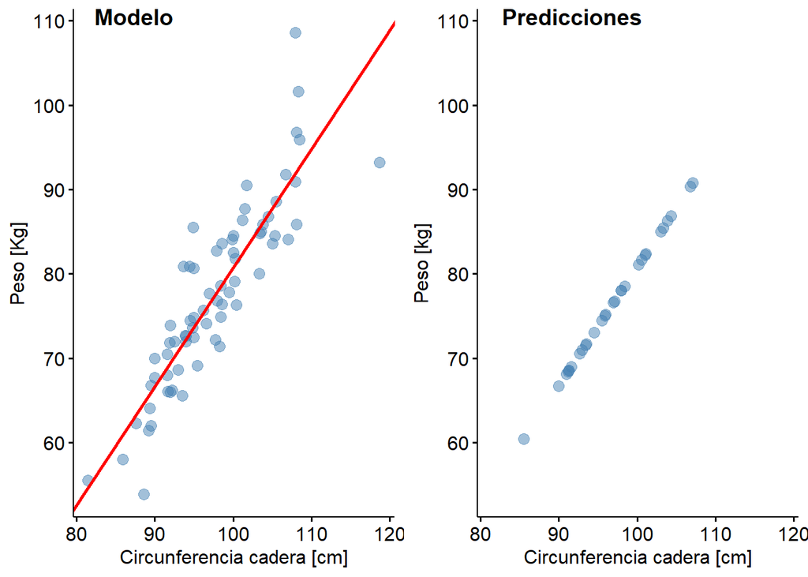

```r
# Predecir peso usando el modelo y los datos de prueba
DatosPredictivoRLS <- data.frame(Hip.Girth = datosPrueba$Hip.Girth)

# Generar predicciones
pred_ingreso <- predict(ModeloRLS, DatosPredictivoRLS)

# Combinar con predicciones
nuevos <- data.frame(Hip.Girth = datosPrueba$Hip.Girth, Weight = pred_ingreso)


# Graficar datos reales
g <- ggscatter(DatosModeloRLS, x = "Hip.Girth", y = "Weight",
               color = "steelblue", fill = "steelblue1", alpha = 0.5, size = 3,
               xlab = "Circunferencia cadera [cm]", ylab = "Peso [Kg]")

# Agregar línea del modelo
g <- g + geom_abline(intercept = coef(ModeloRLS)[1], slope = coef(ModeloRLS)[2],
                     color = "red", size = 1)
# Predecir ingresos usando el modelo
pred_ingreso <- predict(ModeloRLS, data.frame(DatosPredictivoRLS))

nuevos <- data.frame(DatosPredictivoRLS, Weight= pred_ingreso)
# Graficar predicciones
g2 <- ggscatter(nuevos, x = "Hip.Girth", y = "Weight",
                color = "steelblue", fill = "steelblue1", alpha = 0.5, size = 3,
                xlab = "Circunferencia cadera [cm]", ylab = "Peso [kg]")

# Ajustar ejes
g <- ggpar(g, xlim = c(min(DatosModeloRLS$Hip.Girth), max(DatosModeloRLS$Hip.Girth, na.rm = TRUE)), ylim = c(min(DatosModeloRLS$Weight, na.rm = TRUE), max(DatosModeloRLS$Weight, na.rm = TRUE)))
g2 <- ggpar(g2, xlim = c(min(DatosModeloRLS$Hip.Girth), max(DatosModeloRLS$Hip.Girth, na.rm = TRUE)), ylim = c(min(DatosModeloRLS$Weight, na.rm = TRUE), max(DatosModeloRLS$Weight, na.rm = TRUE)))

# Unir gráficos
gf <- ggarrange(g, g2, labels = c("Modelo", "Predicciones"), hjust = c(-1.2, -0.7))
print(gf)
```

Podemos notar que los valores predichos siguen perfectamente la línea de regresión, pues esta representa el promedio de la variable de salida para cada valor del predictor.

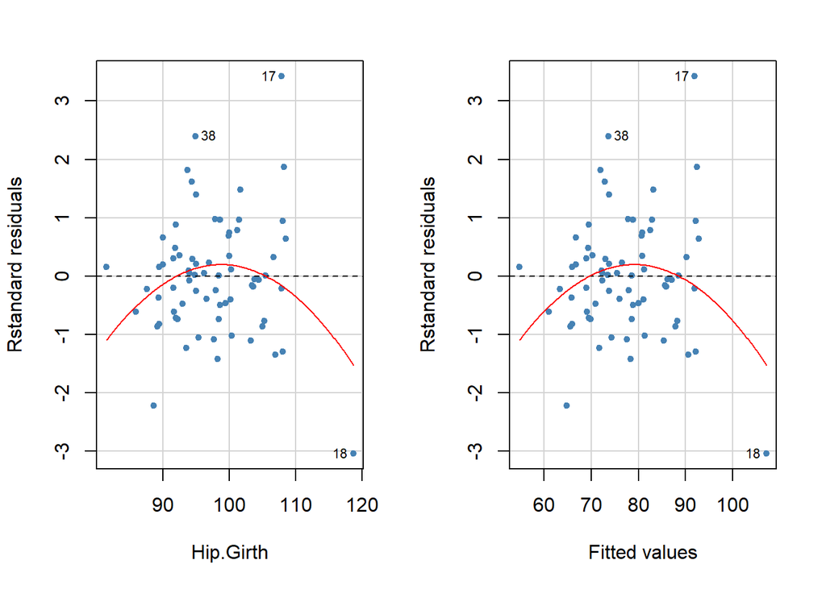

```
##            Test stat Pr(>|Test stat|)
## Hip.Girth    -2.2072          0.03073 *
## Tukey test   -2.2072          0.02730 *
## ---
## Signif. codes:  0 '***' 0.001 '**' 0.01 '*' 0.05 '.' 0.1 ' ' 1
```

```r
residualPlots(ModeloRLS, type="rstandard", id = list(method = "r", n = 3,cex = 0.7, location = "lr"), col = "steelblue", pch = 20, col.quad= "red")
```

```r
set.seed(4263)
db <- durbinWatsonTest(ModeloRLS)
cat("\nPrueba de Independencia: \n")
```

```
##
## Prueba de Independencia:
```